# Project Business Statistics: E-news Express

**Marks: 60**

## Define Problem Statement and Objectives

## Business Context

E-news Express, as an online news portal, aims to expand its business by acquiring new subscribers. With every visitor to the website taking certain actions based on their interest, the company plans to analyze these actions to understand user interests and determine how to drive better engagement. The executives at E-news Express are of the opinion that there has been a decline in new monthly subscribers compared to the past year because the current webpage is not designed well enough in terms of the outline & recommended content to keep customers engaged long enough to make a decision to subscribe.

[Companies often analyze user responses to two variants of a product to decide which of the two variants is more effective. This experimental technique, known as A/B testing, is used to determine whether a new feature attracts users based on a chosen metric.]

## Objective

The design team of the company has researched and created a new landing page that has a new outline & more relevant content shown compared to the old page. In order to test the effectiveness of the new landing page in gathering new subscribers, the Data Science team conducted an experiment by randomly selecting 100 users and dividing them equally into two groups. The existing landing page was served to the first group (control group) and the new landing page to the second group (treatment group). Data regarding the interaction of users in both groups with the two versions of the landing page was collected. Being a data scientist in E-news Express, you have been asked to explore the data and perform a statistical analysis (at a significance level of 5%) to determine the effectiveness of the new landing page in gathering new subscribers for the news portal by answering the following questions:

1. Do the users spend more time on the new landing page than on the existing landing page?
2. Is the conversion rate (the proportion of users who visit the landing page and get converted) for the new page greater than the conversion rate for the old page?
3. Does the converted status depend on the preferred language?
4. Is the time spent on the new page the same for the different language users?

## Data Dictionary

The data contains information regarding the interaction of users in both groups with the two versions of the landing page.

1. user_id - Unique user ID of the person visiting the website
2. group - Whether the user belongs to the first group (control) or the second group (treatment)
3. landing_page - Whether the landing page is new or old
4. time_spent_on_the_page - Time (in minutes) spent by the user on the landing page
5. converted - Whether the user gets converted to a subscriber of the news portal or not
6. language_preferred - Language chosen by the user to view the landing page

## Import all the necessary libraries

```python
import numpy as np
import pandas as pd
from matplotlib import pyplot as plt
import seaborn as sns

%matplotlib inline

import scipy.stats as stats
```

## Reading the Data into a DataFrame

```python
df = pd.read_csv("Desktop/abtest.csv")
```

## Explore the dataset and extract insights using Exploratory Data Analysis

- Data Overview
  - Viewing the first and last few rows of the dataset
  - Checking the shape of the dataset
  - Getting the statistical summary for the variables
- Check for missing values
- Check for duplicates

```python
df.head()
```

|  | user_id | group | landing_page | time_spent_on_the_page | converted | language_preferred |
| --- | --- | --- | --- | --- | --- | --- |
| 0 | 546592 | control | old | 3.48 | no | Spanish |
| 1 | 546468 | treatment | new | 7.13 | yes | English |
| 2 | 546462 | treatment | new | 4.40 | no | Spanish |
| 3 | 546567 | control | old | 3.02 | no | French |
| 4 | 546459 | treatment | new | 4.75 | yes | Spanish |

- The dataset contains the unique IDs of the subscribers, their groups whether is control or treatment. Also the time spent on the page. Whether they converetd or not

```python
df.tail()
```

|  | user_id | group | landing_page | time_spent_on_the_page | converted | language_preferred |
| --- | --- | --- | --- | --- | --- | --- |
| 95 | 546446 | treatment | new | 5.15 | no | Spanish |
| 96 | 546544 | control | old | 6.52 | yes | English |
| 97 | 546472 | treatment | new | 7.07 | yes | Spanish |
| 98 | 546481 | treatment | new | 6.20 | yes | Spanish |
| 99 | 546483 | treatment | new | 5.86 | yes | English |

```python
df.shape
```

```
(100, 6)
```

- The data frame contains 100 rows and 6 columns.

```python
df.info()
```

```
<class 'pandas.core.frame.DataFrame'>
RangeIndex: 100 entries, 0 to 99
Data columns (total 6 columns):
 #   Column                  Non-Null Count  Dtype
---  ------                  --------------  -----
 0   user_id                 100 non-null    int64
 1   group                   100 non-null    object
 2   landing_page            100 non-null    object
 3   time_spent_on_the_page  100 non-null    float64
 4   converted               100 non-null    object
 5   language_preferred      100 non-null    object
dtypes: float64(1), int64(1), object(4)
memory usage: 3.2+ KB
```

There are 100 observations being rows and 6 columns in the data frame. There are 4 objects being group,landing page,converted and language prefered. Also, the data has 1 integer being user id and finally there is also float(64) being time spent on the page

#### Converting Objects into categorical data

```python
for col in ['group', 'landing_page', 'converted', 'language_preferred']:
    df[col] = df[col].astype('category')
```

```python
df.info()
```

```
<class 'pandas.core.frame.DataFrame'>
RangeIndex: 100 entries, 0 to 99
Data columns (total 6 columns):
 #   Column                  Non-Null Count  Dtype
---  ------                  --------------  -----
 0   user_id                 100 non-null    int64
 1   group                   100 non-null    category
 2   landing_page            100 non-null    category
 3   time_spent_on_the_page  100 non-null    float64
 4   converted               100 non-null    category
 5   language_preferred      100 non-null    category
dtypes: category(4), float64(1), int64(1)
memory usage: 2.3 KB
```

There are 100 observations being rows and 6 columns in the data frame. The 4 objects being group,landing page,converted and language prefered has been converted to categorical data. Also, the data has 1 integer being user id and finally there is also float(64) being time spent on the page

```python
df.isnull().sum()
```

```
user_id                   0
group                     0
landing_page              0
time_spent_on_the_page    0
converted                 0
language_preferred        0
dtype: int64
```

There are no missing values in this data frame.

```python
df.duplicated(subset=None, keep='first')
```

```
0     False
1     False
2     False
3     False
4     False
      ...
95    False
96    False
97    False
98    False
99    False
Length: 100, dtype: bool
```

```python
df.describe()
```

|  | user_id | time_spent_on_the_page |
| --- | --- | --- |
| count | 100.000000 | 100.000000 |
| mean | 546517.000000 | 5.377800 |
| std | 52.295779 | 2.378166 |
| min | 546443.000000 | 0.190000 |
| 25% | 546467.750000 | 3.880000 |
| 50% | 546492.500000 | 5.415000 |
| 75% | 546567.250000 | 7.022500 |
| max | 546592.000000 | 10.710000 |

```python
df['group'].value_counts()
```

```
control      50
treatment    50
Name: group, dtype: int64
```

```python
df['landing_page'].value_counts()
```

```
new    50
old    50
Name: landing_page, dtype: int64
```

```python
df['converted'].value_counts()
```

```
yes    54
no     46
Name: converted, dtype: int64
```

```python
df['language_preferred'].value_counts()
```

```
French     34
Spanish    34
English    32
Name: language_preferred, dtype: int64
```

### Univariate Analysis

#### Time spent on the page

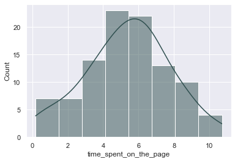

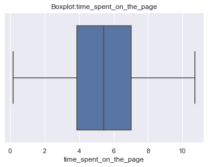

```python
sns.set_theme(style="darkgrid")
sns.histplot(data=df,x='time_spent_on_the_page',kde=True,color="DarkSlateGray");
plt.show();
plt.title('Histogram:time_spent_on_the_page')

sns.boxplot(data=df,x='time_spent_on_the_page');
plt.title('Boxplot:time_spent_on_the_page');
```

#### Observations:

The distribution of the time spent on the page is normally distributed.

#### Group

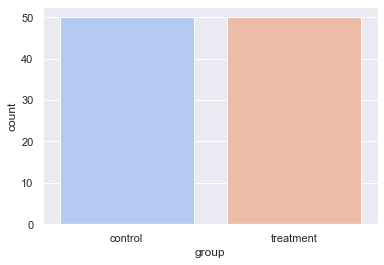

```python
sns.set_theme(style="darkgrid")
sns.countplot(data=df,x='group',palette="coolwarm");
plt.show();
```

#### Observations:

The group is categorised into control and treatment, they have the same frequency of 50.

#### Landing page

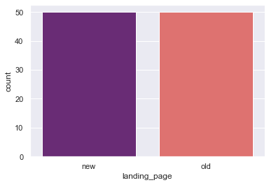

```python
sns.set_theme(style="darkgrid")
sns.countplot(data=df,x='landing_page',palette="magma");
plt.show();
```

#### Observations:

The landing page is categorised into new and old, they both have the same frequency of 50.

#### Converted

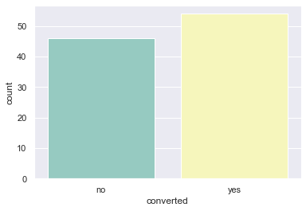

```python
sns.set_theme(style="darkgrid")
sns.countplot(data=df,x='converted',palette="Set3");
plt.show();
```

#### Language prefered

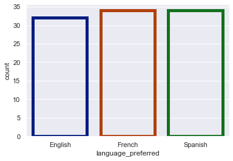

```python
sns.set_theme(style="darkgrid")
sns.countplot(data=df,x='language_preferred',facecolor=(0, 0, 0, 0),
              linewidth=5, edgecolor=sns.color_palette("dark", 3))
plt.show();
```

#### Observations:

As per the histogram above, there are 3 unique languages prefered being English, French and Spanish. Both french and spanish has the frequencies of 34, with Enlish being the least preferred with a frequency of 32.

### Bivariate Analysis

#### Language prefered VS Time spent on the page

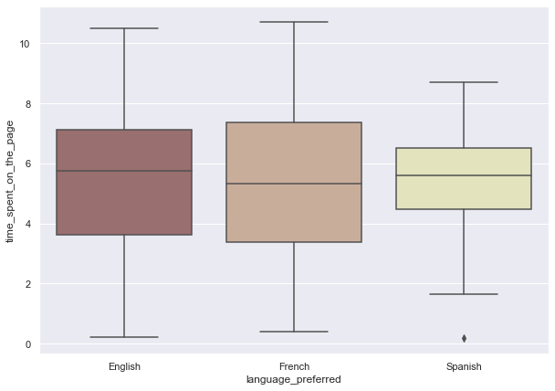

```python
plt.figure(figsize=(10,7))
sns.boxplot(x = "language_preferred", y = "time_spent_on_the_page", data = df, palette = 'pink')
plt.show()
```

```python
df.groupby(['language_preferred'])['time_spent_on_the_page'].mean()
```

```
language_preferred
English    5.559062
French     5.253235
Spanish    5.331765
Name: time_spent_on_the_page, dtype: float64
```

#### Group VS Time spent on the page

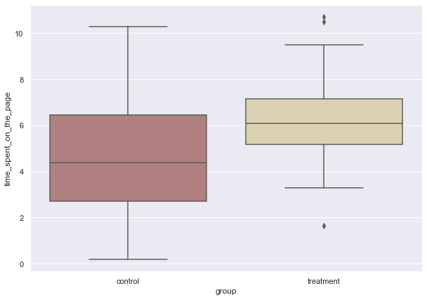

```python
plt.figure(figsize=(10,7))
sns.boxplot(x = "group", y = "time_spent_on_the_page", data = df, palette = 'pink')
plt.show()
```

```python
df.groupby(['group'])['time_spent_on_the_page'].mean()
```

```
group
control      4.5324
treatment    6.2232
Name: time_spent_on_the_page, dtype: float64
```

#### Observations:

Those used as a treatment mostly spend 6.22 minutes as compared to their counter parts Control, they spend less time of 4.53 minutes

#### Converted VS Time spent on the page

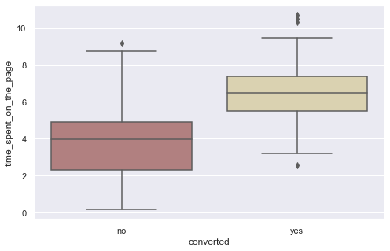

```python
plt.figure(figsize=(8,5))
sns.boxplot(x = "converted", y = "time_spent_on_the_page", data = df, palette = 'pink')
plt.show()
```

```python
df.groupby(['converted'])['time_spent_on_the_page'].mean()
```

```
converted
no     3.915870
yes    6.623148
Name: time_spent_on_the_page, dtype: float64
```

#### Observations:

Those who converted shows that they spent around 6.62 minutes on the site. Those who didnt convert spent 3.92 minutes which is less than the time spent by those who converted

#### Landing page VS Time spent on the page

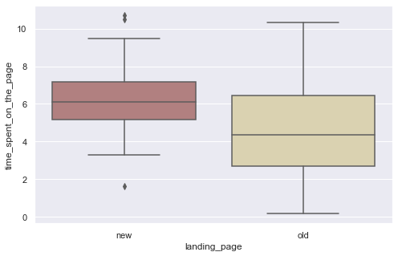

```python
plt.figure(figsize=(8,5))
sns.boxplot(x = "landing_page", y = "time_spent_on_the_page", data = df, palette = 'pink')
plt.show()
```

```python
df.groupby(['landing_page'])['time_spent_on_the_page'].mean()
```

```
landing_page
new    6.2232
old    4.5324
Name: time_spent_on_the_page, dtype: float64
```

## 1. Do the users spend more time on the new landing page than the existing landing page?

### Perform Visual Analysis

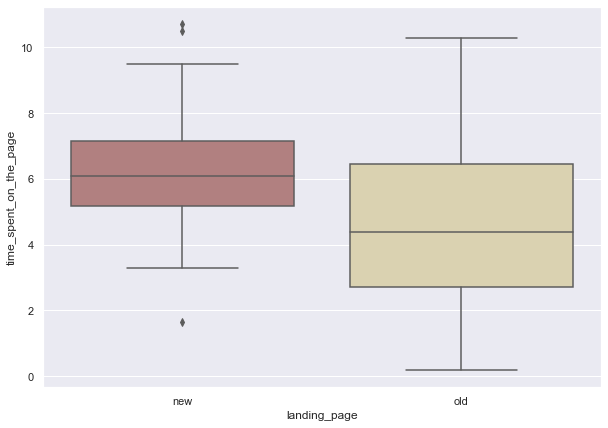

```python
plt.figure(figsize=(10,7))
sns.boxplot(x = "landing_page", y = "time_spent_on_the_page", data = df, palette = 'pink')
plt.show()
```

```python
df.groupby(['landing_page'])['time_spent_on_the_page'].mean()
```

```
landing_page
new    6.2232
old    4.5324
Name: time_spent_on_the_page, dtype: float64
```

### Step 1: Define the null and alternate hypotheses

Let $𝜇_1$ be the mean time spent on the old landing page

and

Let $𝜇_2$ be the mean time spent on the new landing page

The null hypothesis can be written as

> $H_0$: $\mu_1$ = $\mu_2$

against the alternate hypothesis

> $H_a$: $\mu_1$ < $\mu_2$

### Step 3: Decide the significance level

As mentioned in the problem statement, α=0.05

### Step 4: Collect and prepare data

```python
𝜇1  = df[df['landing_page']=='old']['time_spent_on_the_page']
𝜇2 = df[df['landing_page']=='new']['time_spent_on_the_page']
```

```python
print('The sample standard deviation of the time spent on the new page is:', round(𝜇2.std(),2))
print('The sample standard deviation of the time spent on the new page is:', round(𝜇1.std(),2))
```

```
The sample standard deviation of the time spent on the new page is: 1.82
The sample standard deviation of the time spent on the new page is: 2.58
```

Looking at the 2 sample standard deviations not equal, this shows that the population standard deviations are not equal

### Step 5: Calculate the p-value

ttest_rel function from scipy.stats library will be used to perform a two sample paired t-test. This function takes the sample observations from 2 groups

```python
from scipy.stats import ttest_rel


test_stat, p_value  = stats.ttest_rel(𝜇2, 𝜇1, alternative = 'greater')

print('The p-value is', p_value)
```

```
The p-value is 0.00029910900937037973
```

### Step 6: Compare the p-value with $\alpha$

```python
if p_value < 0.05:
    print(f'As the p-value {p_value} is less than the level of significance, we reject the null hypothesis.')
else:
    print(f'As the p-value {p_value} is greater than the level of significance, we fail to reject the null hypothesis.')
```

```
As the p-value 0.00029910900937037973 is less than the level of significance, we reject the null hypothesis.
```

### Step 7: Draw inference

At 5% level of signifance, we reject the null hyphothesis. There is enough statistical evidence that in the new landing page , users spend more time than that of the old landing page.

**A similar approach can be followed to answer the other questions.**

## 2. Is the conversion rate (the proportion of users who visit the landing page and get converted) for the new page greater than the conversion rate for the old page?

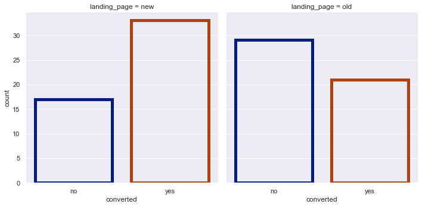

```python
sns.catplot(data = df, x = 'converted', col = 'landing_page', kind = 'count',
            facecolor=(0, 0, 0, 0),linewidth=5,edgecolor=sns.color_palette("dark", 3))
plt.show();
```

By just looking at the 2 histograms above, it shows that there is high conversion rate in the new landing page than that of the old landing page. Also its shows that no convertion of the old page is higher

### Step 1: Define the null and alternate hypotheses

Let p1 the proportion of converted users in the old landing page

and

Let p2 be the proportion of converted users in the New landing page

The null hypothesis can be written as

> $H_0:p_1= p_2$

against the alternate hypothesis

> $H_a:p_1\neq p_2$

### Step 3: Decide the significance level

As level of significance is given at 5%

### Step 4: Collect and prepare data

```python
df.groupby(['landing_page'])['converted'].value_counts()
```

```
landing_page
new           yes    33
              no     17
old           no     29
              yes    21
Name: converted, dtype: int64
```

```python
from statsmodels.stats.proportion import proportions_ztest
```

```python
yes=np.array([21,33])
```

#### 100 users were randomly selected and divided them equally into two groups.

```python
sample=np.array([50,50])
```

### Step 5: Calculate the p-value

```python
test_stat, p_value = proportions_ztest(yes, sample)
print('The p-value is ' + str(p_value))
```

```
The p-value is 0.016052616408112556
```

### Step 6: Compare the p-value with $\alpha$

```python
if p_value < 0.05:
    print(f'As the p-value {p_value} is less than the level of significance, we reject the null hypothesis.')
else:
    print(f'As the p-value {p_value} is greater than the level of significance, we fail to reject the null hypothesis.')
```

```
As the p-value 0.016052616408112556 is less than the level of significance, we reject the null hypothesis.
```

### Step 7: Draw inference

Since the P-value= 0.01605 is less than the level of significance (5%), we reject the null hyphothesis. There is enough statistical evidence that conversion rate among two groups is different.

## 3. Is the conversion and preferred language are independent or related?

```python
df.language_preferred.value_counts()
```

```
French     34
Spanish    34
English    32
Name: language_preferred, dtype: int64
```

As mentioned in the problem statement, there are three types of languages preferred: French, Spanish, and English In the sample of 100 people, 34 each preferred French and Spanish, while 32 preferred English.

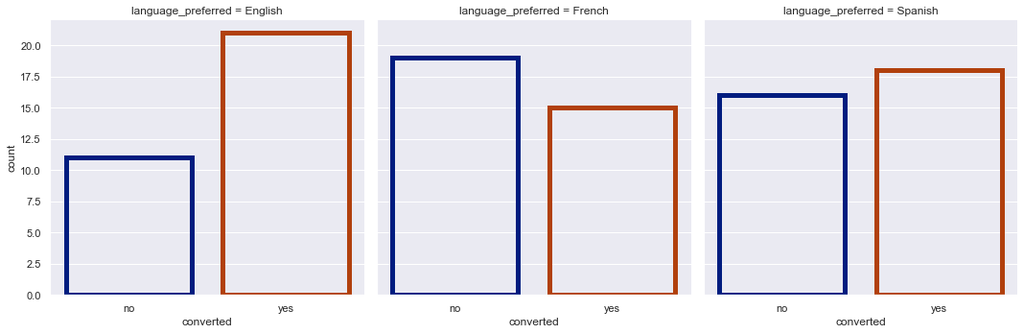

```python
sns.catplot(data = df, x = 'converted', col = 'language_preferred', kind = 'count',
            facecolor=(0, 0, 0, 0),linewidth=5,edgecolor=sns.color_palette("dark", 3))
plt.show();
```

#### Observation:

Conversion seems to have so much effect on the English Language, and it doesnt seem to have so much effect on both French and Spanish languages

### Step 1: Define the null and alternate hypotheses

### Let's write the null and alternative hypothesis

We will test the null hypothesis

> $H_0:$ Conversion is independent of language preferred .

against the alternate hypothesis

> $H_a:$ Conversion depends on language preferred .

### Step 2: Select Appropriate test

The appropriate test for this is a chi-square , this is used to check whether the categorical variables that is conversion and language preferred are independent

### Step 3: Decide the significance level

As level of significance is given at 5%

### Step 4: Collect and prepare data

```python
df1 = df.drop(['group','user_id','time_spent_on_the_page','landing_page'], axis=1)
```

```python
W=pd.crosstab(df1['language_preferred'],df1['converted'])
W
```

| converted language_preferred | no | yes |
| --- | --- | --- |
| English | 11 | 21 |
| French | 19 | 15 |
| Spanish | 16 | 18 |

```python
from scipy.stats import chi2_contingency
```

### Step 5: Calculate the p-value

```python
# find the p-value
chi, p_value, dof, expected = chi2_contingency(W)
print('The p-value is', p_value)
```

```
The p-value is 0.2129888748754345
```

### Step 6: Compare the p-value with $\alpha$

```python
if p_value < 0.05:
    print(f'As the p-value {p_value} is less than the level of significance, we reject the null hypothesis.')
else:
    print(f'As the p-value {p_value} is greater than the level of significance, we fail to reject the null hypothesis.')
```

```
As the p-value 0.2129888748754345 is greater than the level of significance, we fail to reject the null hypothesis.
```

### Step 7: Draw inference

The level of significance is 5%, So since P-value= 0.21299 greater than the 0.05 so we fail reject the null hyphothesis. There is no enough statistical evidence that conversition is dependent on the language preferred

## 4. Is the time spent on the new page same for the different language users?

```python
df_N = df.loc[df['landing_page'] == 'new']
```

```python
df_N.groupby(['language_preferred'])['time_spent_on_the_page'].mean()
```

```
language_preferred
English    6.663750
French     6.196471
Spanish    5.835294
Name: time_spent_on_the_page, dtype: float64
```

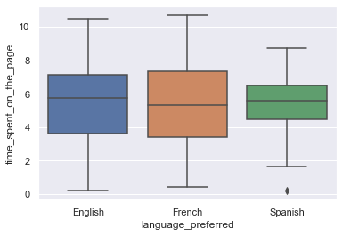

```python
sns.boxplot(x = 'language_preferred', y = 'time_spent_on_the_page',data = df)
plt.show();
```

### Step 1: Define the null and alternate hypotheses

The null and alternative hypotheses can be formulated as:

$H0 :$ The average time spent on the page with respect to languages preferred is equal.

$Ha : $ At least one average time spent on the pages is different among the languages preferred

### Step 2: Select Appropriate test

This problem has 3 population means. One way ANOVA is appropriate test, provided that normality and equality of variance assumptions are satisfied.

For testing of normality, Shapiro-Wilk’s test is applied to the response variable.

For equality of variance, Levene test is applied to the response variable.

##### Shapiro-Wilk’s test

We will test the null hypothesis

$H0:$ The time spent on the pages follow a normal distribution

against the alternative hypothesis

$Ha:$ The time spent on the pages do not follow a normal distribution

```python
w, p_value = stats.shapiro(df_N['time_spent_on_the_page'])
print('The p-value is', p_value)
```

```
The p-value is 0.8040017485618591
```

Since p-value of the test is very large than the 5% significance level, we fail to reject the null hypothesis that the response follows the normal distribution

##### Levene’s test

We will test the null hypothesis

$H0:$ All the population variances are equal

against the alternative hypothesis

$Ha:$ At least one variance is different

```python
statistic, p_value = stats.levene(df_N[df_N['language_preferred']=='English']['time_spent_on_the_page'],
                            df_N[df_N['language_preferred']=='French']['time_spent_on_the_page'],
                            df_N[df_N['language_preferred']=='Spanish']['time_spent_on_the_page'])
print('The p-value is', (p_value))
```

```
The p-value is 0.46711357711340173
```

Since the p-value is larger than the 5% significance level, we fail to reject the null hypothesis of homogeneity of variances.

### Step 3: Decide the significance level

As given in the problem statement, we select α=0.05

### Step 4: Collect and prepare data

```python
language_preferred_E=df_N[df_N['language_preferred']=='English']['time_spent_on_the_page']
language_preferred_F=df_N[df_N['language_preferred']=='French']['time_spent_on_the_page']
language_preferred_S=df_N[df_N['language_preferred']=='Spanish']['time_spent_on_the_page']
```

### Step 5: Calculate the p-value

f_oneway() function from scipy.stats libriary will be used.

```python
from scipy.stats import f_oneway

test_stat, p_value = f_oneway(language_preferred_E, language_preferred_F, language_preferred_S)
print('The p-value is ', p_value)
```

```
The p-value is  0.43204138694325955
```

### Step 6: Compare the p-value with α

```python
if p_value < 0.05:
    print(f'As the p-value {p_value} is less than the level of significance, we reject the null hypothesis.')
else:
    print(f'As the p-value {p_value} is greater than the level of significance, we fail to reject the null hypothesis.')
```

```
As the p-value 0.43204138694325955 is greater than the level of significance, we fail to reject the null hypothesis.
```

### Step 6: Draw Inference

In conclusion,Since we failed to reject the null hypothesis, this shows that the time averages on the new landing page for the different languages are relatively the same.